# Project2

Miguel Corral

23th September 2015

# Overview

This report shows the analysis done upon the ToothGrowth data in the R datasets package.

# Step 1: Load the ToothGrowth data and perform some basic exploratory data analyses

```r
# load data and perform some exploratory data analyses
data(ToothGrowth)
str(ToothGrowth)
```

```
## 'data.frame':    60 obs. of  3 variables:
##  $ len : num  4.2 11.5 7.3 5.8 6.4 10 11.2 11.2 5.2 7 ...
##  $ supp: Factor w/ 2 levels "OJ","VC": 2 2 2 2 2 2 2 2 2 2 ...
##  $ dose: num  0.5 0.5 0.5 0.5 0.5 0.5 0.5 0.5 0.5 0.5 ...
```

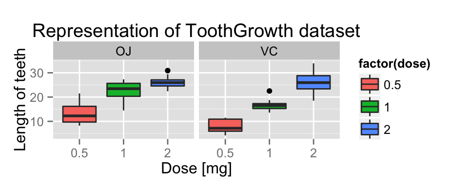

# Step 2: Provide a basic summary of the data

```
##       len        supp         dose
##  Min.   : 4.20   OJ:30   Min.   :0.500
##  1st Qu.:13.07   VC:30   1st Qu.:0.500
##  Median :19.25           Median :1.000
##  Mean   :18.81           Mean   :1.167
##  3rd Qu.:25.27           3rd Qu.:2.000
##  Max.   :33.90           Max.   :2.000
```

# Step 3: Use confidence intervals and/or hypothesis tests to compare tooth growth by supp and dose

Now let’s use confidence intervals for the analysis of different scenarios.

#### Dose alone

```r
dataset <- data.table(ToothGrowth)
t1<-subset(dataset,dose==0.5)$len
t2<-subset(dataset,dose==1)$len
t<-t.test(t1,t2,paired=FALSE,var.equal=FALSE)
t$conf.int[1:2]
```

```
## [1] -11.983781  -6.276219
```

The confidence interval does not contain 0 when increasing the dose level from 0.5 mg to 1 mg, so the null hypotesis (this is this dose does not increase the teeth length) is rejected.

```r
t1<-subset(dataset,dose==1)$len
t2<-subset(dataset,dose==2)$len
t<-t.test(t1,t2,paired=FALSE,var.equal=FALSE)
t$conf.int[1:2]
```

```
## [1] -8.996481 -3.733519
```

Again the null hypotesis is rejected, so the increase of level dose from 1 mg to 2 mg do increase the teeth length.

#### Supplement alone

```r
t1<-subset(dataset,supp=='VC')$len
t2<-subset(dataset,supp=='OJ')$len
t<-t.test(t1,t2,paired=FALSE,var.equal=FALSE)
t$p.value
```

```
## [1] 0.06063451
```

```r
t$conf.int[1:2]
```

```
## [1] -7.5710156  0.1710156
```

#### Supplement by dosage

```r
t1<-subset(dataset,supp=='VC' & dose==0.5)$len
t2<-subset(dataset,supp=='OJ' & dose==0.5)$len
t<-t.test(t1,t2,paired=FALSE,var.equal=FALSE)
t$conf.int[1:2]
```

```
## [1] -8.780943 -1.719057
```

The confidence interval when comparing both supplements at the dose level of 0.5 mg does not contain zero, so the null hypotesis that supplement type when dose is 0.5 level does not affect tooth growth is rejected.

```r
t1<-subset(dataset,supp=='VC' & dose==1)$len
t2<-subset(dataset,supp=='OJ' & dose==1)$len
t<-t.test(t1,t2,paired=FALSE,var.equal=FALSE)
t$conf.int[1:2]
```

```
## [1] -9.057852 -2.802148
```

The confidence interval when comparing both supplements at the dose level of 1 mg does not contain zero, so the null hypotesis that supplement type when dose is 1 level does not affect tooth growth is rejected.

```r
t1<-subset(dataset,supp=='VC' & dose==2)$len
t2<-subset(dataset,supp=='OJ' & dose==2)$len
t<-t.test(t1,t2,paired=FALSE,var.equal=FALSE)
t$p.value
```

```
## [1] 0.9638516
```

```r
t$conf.int[1:2]
```

```
## [1] -3.63807  3.79807
```

The confidence interval when comparing both supplements at the dose level of 2 mg does contain zero this time, and the P-value is almost 1.0, so the null hypotesis (supplement type when dose is 2 level does not affect tooth growth) cannot be rejected.

# Step 4: Conclusions and assumptions

#### Conclusions

- The increase of dose level of Vitamine C alone increases tooth growth.
- Regardless of dose level, supplement type alone does not affect tooth growth.
- For dose levels of 0.5 mg and 1 mg the supplement type of orange juice (OJ) has a greater impact on tooth growth than ascorbic acid (VC), but
- For a dose level of 2 mg, there is no impact on the different type of suplement used (OJ versus VC).

#### Assumptions

- The sample of pigs is representative.
- The dose level and the supplement type were randomly assigned.
- The distribution of the means is normal and the confidence intervals are assumed not to be paired.